# data.table

2015-10-02

## Objective

Using hourly [weather data](http://e-service.cwb.gov.tw/HistoryDataQuery/index.jsp) from 2012-08-15 to 2015-08-14 to illustrate features of data.table.

Special symbols in this data:

- T: trace amount of precipitation
- x: instrument error
- V: wind direction is uncertain

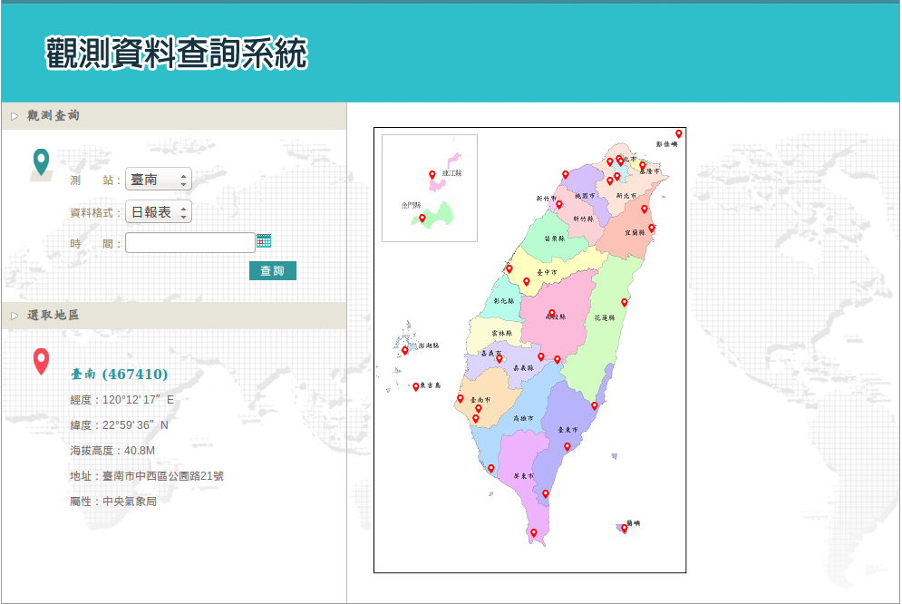

## Installation

Here we use data.table v1.9.5

```r
devtools::install_github("Rdatatable/data.table")
library(data.table)
```

## What is data.table

- An enhanced version of data.frames
- Optimize most heavy works in C
- Minimize redundant copies

## Why data.table

- Speed
- Automatically optimization
- Total solution for ETL
- Concise syntax

## Benchmarks

[Benchmarks : Grouping](https://github.com/Rdatatable/data.table/wiki/Benchmarks-%3A-Grouping)

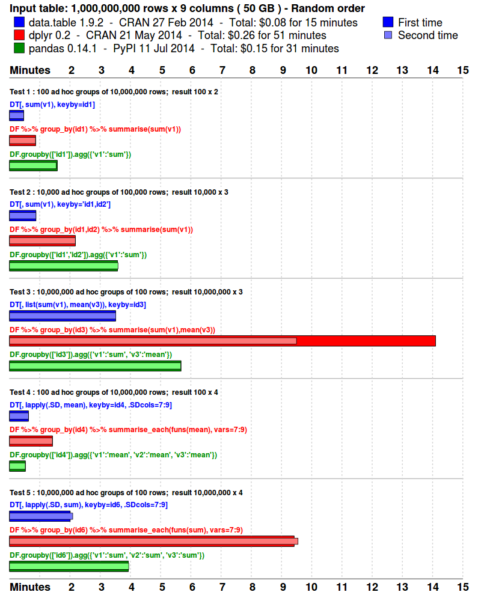

## General Form

**DT[i, j, by]**

| R: | i | j | by |
| --- | --- | --- | --- |
| SQL: | where | select/update | group by |

Take **DT**, subset rows using *i*, then calculate *j*, grouped by *by*.

## Get data

- **fread**: read text file into data.table
- **:=**: add/remove/update a column by reference.
- **rbindlist**: Same as do.call("rbind", l) on data.frames, but faster.

```r
filepaths = list.files("data/daily", full.names = TRUE)
locations = gsub("data\\/daily\\/|_....-..-..\\.csv", "", filepaths)
dates = gsub("data\\/daily\\/.*_|\\.csv", "", filepaths)
weather = list()
for (i in 1:length(filepaths)) {
    weather[[i]] = fread(filepaths[i])
    weather[[i]][, city := locations[i]]
    weather[[i]][, date := dates[i]]
}
weather = rbindlist(weather)
```

## data.table is a data.frame, too

You can use data.table with any function that suitable for data.frame.

```r
class(weather)
```

```
## [1] "data.table" "data.frame"
```

## Benckmark: read data

```r
get_dt = function() {
    dt = list()
    for (i in 1:length(filepaths)) {
        dt[[i]] = fread(filepaths[i])
        dt[[i]][, city := locations[i]]
        dt[[i]][, date := dates[i]]
    }
    rbindlist(dt)
}
```

```r
get_df = function() {
    df = list()
    for (i in 1:length(filepaths)) {
        df[[i]] = read.csv(filepaths[i])
        df[[i]]$city = locations[i]
        df[[i]]$date = dates[i]
    }
    do.call(rbind, df)
}
```

Here we use rbenchmark to test above two functions

```r
library(rbenchmark)
within(benchmark(get_dt(), get_df(), replications = 3,
                 columns=c('test', 'replications', 'elapsed', "relative")),
       { average = elapsed/replications })
```

```
##       test replications elapsed relative  average
## 2 get_df()            3 159.676     2.62 53.22533
## 1 get_dt()            3  60.956     1.00 20.31867
```

## Generate datetime

Here we use lubridate::ymd_h to generate datetime. The warning message is due to the [missing data of Kaohsiung in 2015-06-24](http://e-service.cwb.gov.tw/HistoryDataQuery/DayDataController.do?command=viewMain&station=467440&datepicker=2015-06-24)

```r
weather[,datetime := lubridate::ymd_h(paste(date, ObsTime), tz = "CST")]
```

```
## Warning: 2 failed to parse.
```

```r
weather[is.na(datetime)]
```

```
##                 ObsTime              StnPres                SeaPres
## 1:                   NA                   NA                     NA
## 2: 觀測時間(LST)ObsTime 測站氣壓(hPa)StnPres 海平面氣壓(hPa)SeaPres
##           Temperature              Tddewpoint            RH          WS
## 1:                 NA                      NA            NA          NA
## 2: 氣溫(℃)Temperature 露點溫度(℃)Td dew point 相對溼度(%)RH 風速(m/s)WS
##                             WD              WSGust
## 1:                          NA                  NA
## 2: 風向(最多風向)(360degree)WD 最大陣風(m/s)WSGust
##                           WDGust           Precp             PrecpHour
## 1:                            NA              NA                    NA
## 2: 最大陣風風向(360degree)WDGust 降水量(mm)Precp 降水時數(hr)PrecpHour
##                SunShine                    GloblRad           Visb
## 1:                   NA                          NA             NA
## 2: 日照時數(hr)SunShine 全天空日射量(MJ/㎡)GloblRad 能見度(km)Visb
##         city       date datetime
## 1: Kaohsiung 2015-06-24     <NA>
## 2: Kaohsiung 2015-06-24     <NA>
```

```r
weather = weather[!is.na(datetime),]
str(weather)
```

```
## Classes 'data.table' and 'data.frame':   105096 obs. of  18 variables:
##  $ ObsTime    : chr  "1" "2" "3" "4" ...
##  $ StnPres    : chr  "1002.9 " "1001.5 " "1002.6 " "1002.3 " ...
##  $ SeaPres    : chr  "1005.1 " "1003.7 " "1004.8 " "1004.5 " ...
##  $ Temperature: chr  "28.6 " "28.3 " "28.3 " "28.1 " ...
##  $ Tddewpoint : chr  "21.1 " "22.1 " "21.6 " "21.7 " ...
##  $ RH         : chr  "64 " "69 " "67 " "68 " ...
##  $ WS         : chr  "1.3 " "3.2 " "2.5 " "1.1 " ...
##  $ WD         : chr  "340.0 " "20.0 " "330.0 " "330.0 " ...
##  $ WSGust     : chr  "2.7 " "5.8 " "4.6 " "4.2 " ...
##  $ WDGust     : chr  "310.0 " "40.0 " "20.0 " "320.0 " ...
##  $ Precp      : chr  "0.0 " "0.0 " "0.0 " "0.0 " ...
##  $ PrecpHour  : chr  "0.0 " "0.0 " "0.0 " "0.0 " ...
##  $ SunShine   : chr  " " " " " " " " ...
##  $ GloblRad   : chr  "0.00 " "0.00 " "0.00 " "0.00 " ...
##  $ Visb       : chr  " " "10.0 " " " " " ...
##  $ city       : chr  "Hualien" "Hualien" "Hualien" "Hualien" ...
##  $ date       : chr  "2012-08-15" "2012-08-15" "2012-08-15" "2012-08-15" ...
##  $ datetime   : POSIXct, format: "2012-08-15 01:00:00" "2012-08-15 02:00:00" ...
##  - attr(*, ".internal.selfref")=<externalptr>
```

## Strip numeric columns

- **.SD**: **S**ubset of **D**ata.table. It's a data table that holds the data for the current group defined using *by*.
- **.SDcols** specifies the columns that returned in .SD.

```r
numeric_cols = colnames(weather)[!colnames(weather) %in% c("city", "date", "datetime")]
weather[, c(numeric_cols) := (lapply(.SD, function(x){gsub("[^0-9.TxV]", "", x)})),
        .SDcols = numeric_cols]
```

## Deal with special symbols

You can update partial cells in a data.table.

```r
# Check which numeric columns contain special symbols
weather[, lapply(.SD, function(x){sum(grepl("^[TxV]$", x), na.rm = FALSE)}),
        .SDcol = numeric_cols]
```

```
##    ObsTime StnPres SeaPres Temperature Tddewpoint RH WS  WD WSGust WDGust
## 1:       0       0       0           0          0  0  0 209      0      0
##    Precp PrecpHour SunShine GloblRad Visb
## 1:  3884         0        0        0    0
```

```r
weather[WD == "V", WD := ""]
weather[Precp == "T", Precp := "0"]
```

## More data manipulation

- **:=** also can modify multiple columns by reference in a functional way

```r
weather[, `:=`(month = substr(date, 6, 7),
               isRain = Precp > 0
               )]
weather[, c(numeric_cols) := (lapply(.SD, as.numeric)), .SDcols = numeric_cols]
weather[, date := as.Date(date)]
```

## Select columns

- **.** is an abbreviation of list within data.table
- Because j handle expressions, you need to set **with = FALSE** when slicing with character vector

```r
# Select columns with list
ws = weather[, .(city, datetime, Temperature, Tddewpoint)]

# Select columns with character vector
attrs = c("city", "datetime", "Temperature", "Tddewpoint")
ws2 = weather[, attrs, with = FALSE]
identical(ws, ws2)
```

```
## [1] TRUE
```

## Hottest date and Temperature in each city

- You can use **by** to summarize by each group. **keyby** will add key automatically.
- **.N**: returns the number of rows in the subset.

```r
hottest = ws[, .(datetime, Temperature, T.Max = max(Temperature)), keyby = city]
hottest = hottest[, count := .N]
hottest = hottest[Temperature == T.Max,
                  head(.SD[, .(T.Max, datetime)], 3), # output top 3 to check ties
                  by = city]
hottest
```

```
##         city T.Max            datetime
## 1:   Hualien  35.1 2013-07-12 11:00:00
## 2: Kaohsiung  36.9 2014-09-15 12:00:00
## 3:  Taichung  36.5 2014-09-15 14:00:00
## 4:    Taipei  38.3 2013-08-08 14:00:00
```

## Hottest date and Temperature in each city - 2

- chaining: **DT[ … ][ … ][ … ]**

  Avoid intermediate assignment.

```r
hottest2 = ws[, .(datetime, Temperature, T.Max = max(Temperature)), keyby = city
              ][, count := .N
                ][Temperature == T.Max,
                  head(.SD[, .(T.Max, datetime)], 3), # output top 3 to check ties
                  by = city]
key(hottest2)
```

```
## [1] "city"
```

```r
identical(hottest, hottest2)
```

```
## [1] TRUE
```

## Get Complete dataset

- **CJ**: **C**ross **J**oin. Generate a data.table from the cross product of the vectors.
- **setnames**: Set attributes of data.table by reference.

```r
# cj = CJ(ws$city, ws$datetime, unique = TRUE)  # don't use POSIXct in CJ
cj = CJ(ws$city, as.character(ws$datetime), unique = TRUE)[
    , V2 := lubridate::ymd_hms(V2, tz = "CST")]
setnames(cj, names(cj), c("city", "datetime"))
ws = merge(cj, ws, all.x = TRUE, all.y = FALSE, by = c("city", "datetime"))
ws[, date := as.character(datetime)][,
    `:=`(date = as.Date(substr(date, 1, 10)),
         year = substr(date, 1, 4),
         month = substr(date, 6, 7),
         hour = substr(date, 12, 13))]
```

## Get Complete dataset - 2

```r
ws[city == "Kaohsiung" & date == as.Date("2015-06-24"), ]
```

```
##          city            datetime Temperature Tddewpoint       date year
##  1: Kaohsiung 2015-06-24 00:00:00        29.4       24.7 2015-06-24 2015
##  2: Kaohsiung 2015-06-24 01:00:00          NA         NA 2015-06-24 2015
##  3: Kaohsiung 2015-06-24 02:00:00          NA         NA 2015-06-24 2015
##  4: Kaohsiung 2015-06-24 03:00:00          NA         NA 2015-06-24 2015
##  5: Kaohsiung 2015-06-24 04:00:00          NA         NA 2015-06-24 2015
##  6: Kaohsiung 2015-06-24 05:00:00          NA         NA 2015-06-24 2015
##  7: Kaohsiung 2015-06-24 06:00:00          NA         NA 2015-06-24 2015
##  8: Kaohsiung 2015-06-24 07:00:00          NA         NA 2015-06-24 2015
##  9: Kaohsiung 2015-06-24 08:00:00          NA         NA 2015-06-24 2015
## 10: Kaohsiung 2015-06-24 09:00:00          NA         NA 2015-06-24 2015
## 11: Kaohsiung 2015-06-24 10:00:00          NA         NA 2015-06-24 2015
## 12: Kaohsiung 2015-06-24 11:00:00          NA         NA 2015-06-24 2015
## 13: Kaohsiung 2015-06-24 12:00:00          NA         NA 2015-06-24 2015
## 14: Kaohsiung 2015-06-24 13:00:00          NA         NA 2015-06-24 2015
```

[output cut: 37 more lines]

## Interpolate NA with mean

- We can subset row by a particular columns after assiggn it as a key with **setkey**.
- **set** is used to repeatedly update rows and columns by reference.

```r
inter_mean = ws[year == "2015" & month == "06" & city == "Kaohsiung",
                .(meanT = mean(Temperature, na.rm = TRUE),
                  meanTd = mean(Tddewpoint, na.rm = TRUE)),
                by = hour]
setkey(inter_mean, hour)
Tj = which(colnames(ws) == "Temperature")
Tdj = which(colnames(ws) == "Tddewpoint")
for (i in which(is.na(ws$Temperature))) {
    set(ws, i, Tj, inter_mean[ws[i, hour], meanT])
    set(ws, i, Tdj, inter_mean[ws[i, hour], meanTd])
}
```

## Interpolate NA with mean -2

```r
ws[city == "Kaohsiung" & date == as.Date("2015-06-24"), ]
```

```
##          city            datetime Temperature Tddewpoint       date year
##  1: Kaohsiung 2015-06-24 00:00:00    29.40000   24.70000 2015-06-24 2015
##  2: Kaohsiung 2015-06-24 01:00:00    29.40345   25.12069 2015-06-24 2015
##  3: Kaohsiung 2015-06-24 02:00:00    29.24138   24.95172 2015-06-24 2015
##  4: Kaohsiung 2015-06-24 03:00:00    28.99655   24.77586 2015-06-24 2015
##  5: Kaohsiung 2015-06-24 04:00:00    28.80690   24.67586 2015-06-24 2015
##  6: Kaohsiung 2015-06-24 05:00:00    28.57241   24.51379 2015-06-24 2015
##  7: Kaohsiung 2015-06-24 06:00:00    28.65517   24.47586 2015-06-24 2015
##  8: Kaohsiung 2015-06-24 07:00:00    29.74483   25.23103 2015-06-24 2015
##  9: Kaohsiung 2015-06-24 08:00:00    30.87586   25.63448 2015-06-24 2015
## 10: Kaohsiung 2015-06-24 09:00:00    31.35172   25.98276 2015-06-24 2015
## 11: Kaohsiung 2015-06-24 10:00:00    31.82414   26.42069 2015-06-24 2015
## 12: Kaohsiung 2015-06-24 11:00:00    32.22069   26.47586 2015-06-24 2015
## 13: Kaohsiung 2015-06-24 12:00:00    32.45172   26.61034 2015-06-24 2015
## 14: Kaohsiung 2015-06-24 13:00:00    32.60000   26.65172 2015-06-24 2015
```

[output cut: 37 more lines]

## Compute regression coefficient in each city

In this example, all values are concatenate into single column.

```r
ws[, .(coef(lm(Tddewpoint ~ Temperature))), by = city]
```

```
##         city         V1
## 1:   Hualien -2.7831813
## 2:   Hualien  0.9292042
## 3: Kaohsiung -5.8939668
## 4: Kaohsiung  1.0290631
## 5:  Taichung -1.2627112
## 6:  Taichung  0.8169720
## 7:    Taipei -2.0428652
## 8:    Taipei  0.8500687
```

## Compute regression coefficient in each city - 2

As long as j returns a list, each element of the list will become a column in the resulting data.table.

```r
ws[, as.list(coef(lm(Tddewpoint ~ Temperature))), by = city]
```

```
##         city (Intercept) Temperature
## 1:   Hualien   -2.783181   0.9292042
## 2: Kaohsiung   -5.893967   1.0290631
## 3:  Taichung   -1.262711   0.8169720
## 4:    Taipei   -2.042865   0.8500687
```

## Sort

Sort Temperature in ascending and Tddewpoint in descending

- **order** in data.table acts just like base::order, but faster.
- **-** means decending.

```r
ws[order(Temperature, -Tddewpoint)]
```

```
##             city            datetime Temperature Tddewpoint       date
##      1: Taichung 2014-02-21 06:00:00         6.8        3.7 2014-02-21
##      2: Taichung 2014-02-21 05:00:00         7.2        4.5 2014-02-21
##      3: Taichung 2014-02-21 04:00:00         7.4        2.9 2014-02-21
##      4: Taichung 2014-01-23 05:00:00         7.6        5.3 2014-01-23
##      5: Taichung 2014-01-23 07:00:00         7.7        5.2 2014-01-23
##     ---
## 105116:   Taipei 2014-08-02 12:00:00        37.4       24.3 2014-08-02
## 105117:   Taipei 2014-07-09 13:00:00        37.5       25.9 2014-07-09
## 105118:   Taipei 2013-08-08 15:00:00        37.7       25.0 2013-08-08
## 105119:   Taipei 2013-08-08 13:00:00        37.8       24.4 2013-08-08
## 105120:   Taipei 2013-08-08 14:00:00        38.3       25.4 2013-08-08
##         year month hour
##      1: 2014    02   06
##      2: 2014    02   05
##      3: 2014    02   04
##      4: 2014    01   05
##      5: 2014    01   07
##     ---
## 105116: 2014    08   12
## 105117: 2014    07   13
## 105118: 2013    08   15
## 105119: 2013    08   13
## 105120: 2013    08   14
```

## Benckmark: order

```r
order_dt = function(ws) {
    ws[order(city, datetime)]
    ws[order(Temperature, -Tddewpoint)]
}
```

```r
order_base = function(ws) {
    ws[base::order(city, datetime)]
    ws[base::order(Temperature, -Tddewpoint)]
}
```

Here we use rbenchmark to test above two functions

```r
within(benchmark(order_dt_out <- order_dt(ws),
                 order_base_out <- order_base(ws),
                 replications = 10,
                 columns=c('test', 'replications', 'elapsed', "relative")),
       { average = elapsed/replications })
```

```
##                               test replications elapsed relative average
## 2 order_base_out <- order_base(ws)           10   1.912    4.585  0.1912
## 1     order_dt_out <- order_dt(ws)           10   0.417    1.000  0.0417
```

```r
identical(order_dt_out, order_base_out)
```

```
## [1] TRUE
```

## copy

**:=** and **set*** modify the data.table by references. You can use *copy* to do a deep copy to avoid side effect(modify a object within a function).

```r
deepf = function(dt) {
    dt = copy(dt)
    dt[, city := substr(city, 1, 1)]
}
deepf(hottest2)
hottest2
```

```
##         city T.Max            datetime
## 1:   Hualien  35.1 2013-07-12 11:00:00
## 2: Kaohsiung  36.9 2014-09-15 12:00:00
## 3:  Taichung  36.5 2014-09-15 14:00:00
## 4:    Taipei  38.3 2013-08-08 14:00:00
```

```r
shallowf = function(dt) {
    dt[, city := substr(city, 1, 1)]
}
shallowf(hottest2)
hottest2
```

```
##    city T.Max            datetime
## 1:    H  35.1 2013-07-12 11:00:00
## 2:    K  36.9 2014-09-15 12:00:00
## 3:    T  36.5 2014-09-15 14:00:00
## 4:    T  38.3 2013-08-08 14:00:00
```

## melt.data.table

data.table implement melt in reshape2. Additionally, you can use regular expression with patterns to melt multiple columns.

```r
melted = melt.data.table(weather,
                         id.vars = c("city", "datetime"),
                         measure = patterns(".*Pres", "Precp"),
                         value.name = c("Pres", "Precp")
                         )
melted[c(1,2,.N-1,.N),]
```

```
##       city            datetime variable   Pres Precp
## 1: Hualien 2012-08-15 01:00:00        1 1002.9     0
## 2: Hualien 2012-08-15 02:00:00        1 1001.5     0
## 3:  Taipei 2015-08-14 23:00:00        2 1008.7     0
## 4:  Taipei 2015-08-15 00:00:00        2 1008.4     0
```

## dcast.data.table

You can also use dcast with data.table. Furthermore, you can cast multiple value.vars simultaneously.

```r
dcasted = dcast.data.table(melted, city + datetime ~ variable,
                           value.var = c("Pres", "Precp"))
dcasted[c(1,2,.N-1,.N),]
```

```
##       city            datetime Pres_1 Pres_2 Precp_1 Precp_2
## 1: Hualien 2012-08-15 01:00:00 1002.9 1005.1       0       0
## 2: Hualien 2012-08-15 02:00:00 1001.5 1003.7       0       0
## 3:  Taipei 2015-08-14 23:00:00 1005.2 1008.7       0       0
## 4:  Taipei 2015-08-15 00:00:00 1004.9 1008.4       0       0
```

## References

- [data.table wiki - Getting started](https://github.com/Rdatatable/data.table/wiki/Getting-started)
- [The data.table Cheat Sheet](http://www.r-bloggers.com/the-data-table-cheat-sheet/)
- [Data Analysis in R, the data.table Way](https://www.datacamp.com/courses/data-table-data-manipulation-r-tutorial)
- [Benchmarks : Grouping](https://github.com/Rdatatable/data.table/wiki/Benchmarks-%3A-Grouping)